# IODS course project

## 3. PCA with Standardized variables

Below we repeat the above analysis but after standardizing the variables in the human data.

The results are quite different to the PCA with non-standardized variables. The GNI in the non-standardized dataset has values ranging from over one hundred thousand down to five hundred whereas the next largest range in another variable is much lower, from 0.6 to 204.8. This makes variance in any other variable seem inconsequential. PCA is sensitive to the scaling of the features and assumes that features with larger variance are more important than features with smaller variance.

In this new analysis PC1 captures 53.6% of the variance and PC2 captures 16.2% which is 69.8% combined, much less than for the PCA in section 2.

The small angle between several of the arrows indicates high positive correlation between their features. Mat.Mor with Ado.Birth; Parli.F with Labo.FM; and between Edu.Exp, Life.Exp, GNI and Edu2.FM

```r
# standardizing the variables
human_std <- scale(human)

# Principal Component Analysis with the Singular Value Decomposition method and a summary
pca_human <- prcomp(human_std)
s <- summary(pca_human)
s
```

```
## Importance of components:
##                           PC1    PC2     PC3     PC4     PC5     PC6
## Standard deviation     2.0708 1.1397 0.87505 0.77886 0.66196 0.53631
## Proportion of Variance 0.5361 0.1624 0.09571 0.07583 0.05477 0.03595
## Cumulative Proportion  0.5361 0.6984 0.79413 0.86996 0.92473 0.96069
##                            PC7     PC8
## Standard deviation     0.45900 0.32224
## Proportion of Variance 0.02634 0.01298
## Cumulative Proportion  0.98702 1.00000
```

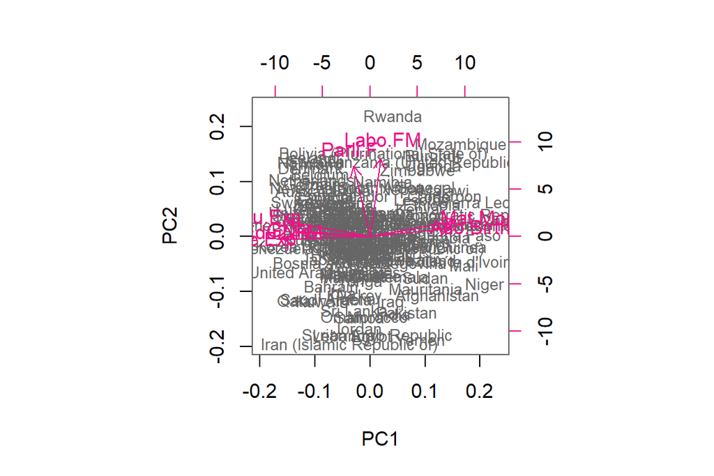

```r
# Draw a biplot displaying the observations by the first two principal components (PC1 coordinate in x-axis, PC2 coordinate in y-axis), along with arrows representing the original variables.
biplot(pca_human, choices = 1:2, cex = c(0.8, 1), col = c("grey40", "deeppink2"))
```

## 4. Interpretations

PC1 is highly positively correlated with Mat.Mor and Ado.Birth, shown in the biplot by the small angle between the arrows of those two features and the X-axis.

PC2 is highly positively correlated with Labo.FM and Parli.F.

So we can say that the highest variability between countries in this data set relates to adolecents giving birth and mothers dying in childbirth. Secondly that a significant but lesser variation between countries relates to women entering the labour force and parliment. PC1 and PC2 only cover 69.8% of the variance which means that there is significant variance in other components.

## 5. MCA on tea data

### 5a. The tea dataset

Loading the tea dataset from the package Factominer and a brief exploration.

```r
# loading FactoMineR and the tea dataset
library(FactoMineR)
data(tea)

# Exploring the data
dim(tea)
```

```
## [1] 300  36
```

```r
str(tea)
```

```
## 'data.frame':    300 obs. of  36 variables:
##  $ breakfast       : Factor w/ 2 levels "breakfast","Not.breakfast": 1 1 2 2 1 2 1 2 1 1 ...
##  $ tea.time        : Factor w/ 2 levels "Not.tea time",..: 1 1 2 1 1 1 2 2 2 1 ...
##  $ evening         : Factor w/ 2 levels "evening","Not.evening": 2 2 1 2 1 2 2 1 2 1 ...
##  $ lunch           : Factor w/ 2 levels "lunch","Not.lunch": 2 2 2 2 2 2 2 2 2 2 ...
##  $ dinner          : Factor w/ 2 levels "dinner","Not.dinner": 2 2 1 1 2 1 2 2 2 2 ...
##  $ always          : Factor w/ 2 levels "always","Not.always": 2 2 2 2 1 2 2 2 2 2 ...
##  $ home            : Factor w/ 2 levels "home","Not.home": 1 1 1 1 1 1 1 1 1 1 ...
##  $ work            : Factor w/ 2 levels "Not.work","work": 1 1 2 1 1 1 1 1 1 1 ...
##  $ tearoom         : Factor w/ 2 levels "Not.tearoom",..: 1 1 1 1 1 1 1 1 1 2 ...
##  $ friends         : Factor w/ 2 levels "friends","Not.friends": 2 2 1 2 2 2 1 2 2 2 ...
##  $ resto           : Factor w/ 2 levels "Not.resto","resto": 1 1 2 1 1 1 1 1 1 1 ...
##  $ pub             : Factor w/ 2 levels "Not.pub","pub": 1 1 1 1 1 1 1 1 1 1 ...
##  $ Tea             : Factor w/ 3 levels "black","Earl Grey",..: 1 1 2 2 2 2 2 1 2 1 ...
##  $ How             : Factor w/ 4 levels "alone","lemon",..: 1 3 1 1 1 1 1 3 3 1 ...
```

[output cut: 22 more lines]

[figure not shown]

```r
# Visualising the data
library(ggplot2)
library(dplyr)
library(tidyr)
# ggplot2, dplyr and tidyr are available ***********************************


# visualizing the dataset.
gather(tea) %>% ggplot(aes(value)) + facet_wrap("key", scales = "free") + geom_bar() + theme(axis.text.x = element_text(angle = 45, hjust = 1, size = 8))
```

```r
# 36 variables is too much to see anything in this kind of visualisation. Let's reduce it to a few variables of interest.

# defining columns to keep in the dataset
keep_columns <- c("Tea", "How", "price", "sugar", "where", "home")

# select the 'keep_columns' to create a new dataset
tea_time <- dplyr::select(tea, one_of(keep_columns))

# look at the summaries and structure of the data
summary(tea_time)
```

```
##         Tea         How                  price          sugar
##  black    : 74   alone:195   p_branded      : 95   No.sugar:155
##  Earl Grey:193   lemon: 33   p_cheap        :  7   sugar   :145
##  green    : 33   milk : 63   p_private label: 21
##                  other:  9   p_unknown      : 12
##                              p_upscale      : 53
##                              p_variable     :112
##                   where           home
##  chain store         :192   home    :291
##  chain store+tea shop: 78   Not.home:  9
##  tea shop            : 30
##
##
##
```

```r
str(tea_time)
```

```
## 'data.frame':    300 obs. of  6 variables:
##  $ Tea  : Factor w/ 3 levels "black","Earl Grey",..: 1 1 2 2 2 2 2 1 2 1 ...
##  $ How  : Factor w/ 4 levels "alone","lemon",..: 1 3 1 1 1 1 1 3 3 1 ...
##  $ price: Factor w/ 6 levels "p_branded","p_cheap",..: 4 6 6 6 6 3 6 6 5 5 ...
##  $ sugar: Factor w/ 2 levels "No.sugar","sugar": 2 1 1 2 1 1 1 1 1 1 ...
##  $ where: Factor w/ 3 levels "chain store",..: 1 1 1 1 1 1 1 1 2 2 ...
##  $ home : Factor w/ 2 levels "home","Not.home": 1 1 1 1 1 1 1 1 1 1 ...
```

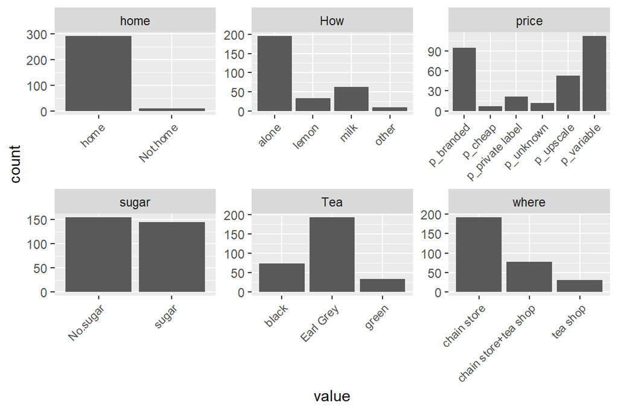

```r
# visualisation of the dataset with fewer variables
gather(tea_time) %>% ggplot(aes(value)) + facet_wrap("key", scales = "free") + geom_bar() + theme(axis.text.x = element_text(angle = 45, hjust = 1, size = 8))
```

### 5b. MCA

Multiple Correspondence Analysis on six columns of the tea data.

With the numbers listed under categorical variables below, a value close to 1 indicates a strong link between the variable and dimension. The highest values are 0.643 for price in relation to Dimension 1 and where in relation to dimensions 1 and two with 0.636 and 0.567 respectively.

We can see from their proximity in the plot that having lemon with your tea is most often associated with the tea being black.

```r
# multiple correspondence analysis.
mca <- MCA(tea_time, graph = FALSE)

# summary of the model
summary(mca)
```

```
##
## Call:
## MCA(X = tea_time, graph = FALSE)
##
##
## Eigenvalues
##                        Dim.1   Dim.2   Dim.3   Dim.4   Dim.5   Dim.6
## Variance               0.282   0.242   0.221   0.205   0.180   0.170
## % of var.             12.081  10.373   9.473   8.777   7.695   7.288
## Cumulative % of var.  12.081  22.454  31.927  40.704  48.399  55.687
##                        Dim.7   Dim.8   Dim.9  Dim.10  Dim.11  Dim.12
## Variance               0.168   0.166   0.146   0.141   0.127   0.115
## % of var.              7.198   7.094   6.265   6.050   5.434   4.917
## Cumulative % of var.  62.885  69.978  76.243  82.293  87.727  92.644
##                       Dim.13  Dim.14
## Variance               0.104   0.068
## % of var.              4.458   2.899
## Cumulative % of var.  97.101 100.000
##
## Individuals (the 10 first)
##                    Dim.1    ctr   cos2    Dim.2    ctr   cos2    Dim.3
## 1               | -0.302  0.108  0.019 | -0.007  0.000  0.000 | -0.367
## 2               |  0.104  0.013  0.006 | -0.365  0.184  0.080 | -0.710
## 3               | -0.169  0.034  0.040 | -0.160  0.035  0.036 | -0.099
## 4               | -0.381  0.172  0.197 | -0.159  0.035  0.034 |  0.282
## 5               | -0.169  0.034  0.040 | -0.160  0.035  0.036 | -0.099
## 6               | -0.446  0.235  0.075 |  0.269  0.100  0.027 | -0.209
## 7               | -0.169  0.034  0.040 | -0.160  0.035  0.036 | -0.099
## 8               |  0.104  0.013  0.006 | -0.365  0.184  0.080 | -0.710
## 9               |  0.680  0.547  0.217 | -0.319  0.140  0.048 |  0.029
## 10              |  0.984  1.144  0.481 | -0.137  0.026  0.009 | -0.350
##                    ctr   cos2
## 1                0.203  0.028 |
## 2                0.761  0.302 |
## 3                0.015  0.014 |
## 4                0.120  0.107 |
## 5                0.015  0.014 |
## 6                0.066  0.016 |
## 7                0.015  0.014 |
## 8                0.761  0.302 |
```

[output cut: 20 more lines]

```
## lemon           -0.996 |  1.475 18.046  0.269  8.967 |
## milk            -2.948 | -0.398  2.507  0.042 -3.547 |
## other           -7.011 | -1.076  2.620  0.036 -3.273 |
## p_branded        4.385 | -0.254  1.543  0.030 -2.992 |
## p_cheap         -1.136 | -0.705  0.874  0.012 -1.884 |
## p_private label  2.706 | -0.136  0.097  0.001 -0.643 |
##
## Categorical variables (eta2)
##                   Dim.1 Dim.2 Dim.3
## Tea             | 0.160 0.292 0.382 |
## How             | 0.102 0.223 0.311 |
## price           | 0.643 0.337 0.062 |
## sugar           | 0.114 0.000 0.288 |
## where           | 0.636 0.567 0.117 |
## home            | 0.037 0.034 0.165 |
```

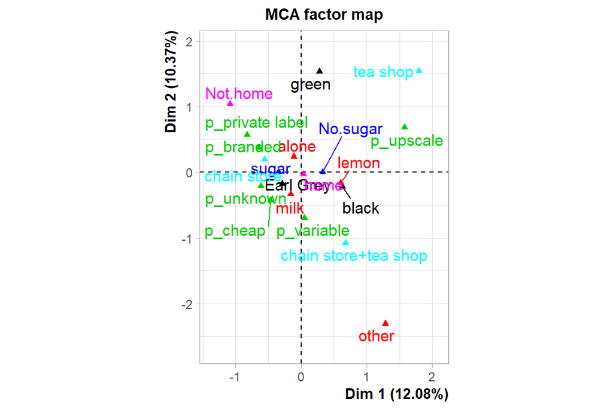

```r
# visualize MCA.
plot(mca, invisible=c("ind"), habillage = "quali")
```

```r
# create and print out a summary of mca
mca_summary <- summary(mca)
```

```
##
## Call:
## MCA(X = tea_time, graph = FALSE)
##
##
## Eigenvalues
##                        Dim.1   Dim.2   Dim.3   Dim.4   Dim.5   Dim.6
## Variance               0.282   0.242   0.221   0.205   0.180   0.170
## % of var.             12.081  10.373   9.473   8.777   7.695   7.288
## Cumulative % of var.  12.081  22.454  31.927  40.704  48.399  55.687
##                        Dim.7   Dim.8   Dim.9  Dim.10  Dim.11  Dim.12
## Variance               0.168   0.166   0.146   0.141   0.127   0.115
## % of var.              7.198   7.094   6.265   6.050   5.434   4.917
## Cumulative % of var.  62.885  69.978  76.243  82.293  87.727  92.644
##                       Dim.13  Dim.14
## Variance               0.104   0.068
## % of var.              4.458   2.899
## Cumulative % of var.  97.101 100.000
##
## Individuals (the 10 first)
##                    Dim.1    ctr   cos2    Dim.2    ctr   cos2    Dim.3
## 1               | -0.302  0.108  0.019 | -0.007  0.000  0.000 | -0.367
## 2               |  0.104  0.013  0.006 | -0.365  0.184  0.080 | -0.710
## 3               | -0.169  0.034  0.040 | -0.160  0.035  0.036 | -0.099
## 4               | -0.381  0.172  0.197 | -0.159  0.035  0.034 |  0.282
## 5               | -0.169  0.034  0.040 | -0.160  0.035  0.036 | -0.099
## 6               | -0.446  0.235  0.075 |  0.269  0.100  0.027 | -0.209
## 7               | -0.169  0.034  0.040 | -0.160  0.035  0.036 | -0.099
## 8               |  0.104  0.013  0.006 | -0.365  0.184  0.080 | -0.710
## 9               |  0.680  0.547  0.217 | -0.319  0.140  0.048 |  0.029
## 10              |  0.984  1.144  0.481 | -0.137  0.026  0.009 | -0.350
##                    ctr   cos2
## 1                0.203  0.028 |
## 2                0.761  0.302 |
## 3                0.015  0.014 |
## 4                0.120  0.107 |
## 5                0.015  0.014 |
## 6                0.066  0.016 |
## 7                0.015  0.014 |
## 8                0.761  0.302 |
```

[output cut: 20 more lines]

```
## lemon           -0.996 |  1.475 18.046  0.269  8.967 |
## milk            -2.948 | -0.398  2.507  0.042 -3.547 |
## other           -7.011 | -1.076  2.620  0.036 -3.273 |
## p_branded        4.385 | -0.254  1.543  0.030 -2.992 |
## p_cheap         -1.136 | -0.705  0.874  0.012 -1.884 |
## p_private label  2.706 | -0.136  0.097  0.001 -0.643 |
##
## Categorical variables (eta2)
##                   Dim.1 Dim.2 Dim.3
## Tea             | 0.160 0.292 0.382 |
## How             | 0.102 0.223 0.311 |
## price           | 0.643 0.337 0.062 |
## sugar           | 0.114 0.000 0.288 |
## where           | 0.636 0.567 0.117 |
## home            | 0.037 0.034 0.165 |
```

```r
mca_summary
```

```r
# rounded percetanges of variance captured by each PC
mca_pr <- round(1*mca_summary$importance[2, ], digits = 1)

# print out the percentages of variance
mca_pr
```

```
## numeric(0)
```

```r
# create object pc_lab to be used as axis labels
pc_labels <- paste0(names(mca_pr), " (", mca_pr, "%)")
```